[output not shown]

[figure not shown]

# 1. Frozen回测框架逻辑介绍

## 1.1 导入回测框架

```
from Framework import *
```

## 1.2 常规编写步骤

[figure not shown]

如图为Frozen系统主界面，

在terminal中运行Framework.py文件，等待数据获取/更新，待进度条走完，输出表格，净值曲线图

首先，初始化框架参数

```python
# Framework
index_code = 'tushare支持指数类型'
start_date = None
end_date = TODAY
max_stocks = 5
date_rule = 4
csv = True
html = True

# Util
PATH = './data cache'
token = 'tushare社区token'

# Client
init_capital = 1e6
slippage = 0.0001
commission = 0.0003
stamp_duty = 0.001
ub = np.Inf
lb = -0.08
slippage_type = 'byRate'
```

## 1.3 模块说明

### （1） Framework

**Framework**是策略框架，起统筹规划的作用。它有两个任务：负责记录交易状态，计算每天的损益，生成交易日志，并根据持仓输出给出交易信号；进行绩效评估，绘制策略净值曲线，计算各种评价指标。

```python
alpha = Framework(index_code = '000905.SH', start_date = '20230101', end_date = '20230726', max_stocks = 5, date_rule = 4)
alpha.result_analysis(csv = True, html = False)
```

其调用方法如上所示，

Framework(index_code, start_date=None, end_date=None, max_stocks=5, date_rule=4)

Invoke Frozen backtest framework and initialize data flow.

> **Parameters:** - index_code (`str`) - String object denoting benchmark to trace - start_date (`str`, *optional*) - The strategy start date of format “YYYYmmdd” - end_date (`str`, *optional*) - The strategy end date of format “YYYYmmdd” - max_stocks (`int`, *defalut*: `5`) - Max number of stocks to hold, normally set larger than 3 - date_rule (`int`, *defalut*: `4`) - Day of week for position adjustment following the strategy weekday rule [“1”-“Mon”, “2”-“Tue”, “3”-“Wed”, “4”-“Thu”, “5”-“Fri”]

> **Returns:** - Frozen framework (`class`)

Framework.result_analysis(csv=True, html=True)

Quantify strategy performance by creating charts and plotting relevant graphs.

此外，Framework会自动生成交易日志，并对特殊的activities进行记录，除日常INFO记录持仓外，会有以下三个WARNING级别的记录：

- Portfolio reallocation day is holiday, rebalancing deferred to next trading day.
- Stop-loss point occurs for xxx on YYYY-mm-dd, closing long position.
- Dividend incident occurs for xxx on YYYY-mm-dd

### （2）AlphaBase

**AlphaBase**是策略主体，也是整个策略的核心。所有的因子研究、因子合成都在这个模块里进行，下面是一段简单的因子合成示例代码。

```python
def factor_mining(self):
    wms = pd.DataFrame({tic: ((data['hfq_high'].rolling(self.window).max() - data['hfq_close']) / (data['hfq_high'].rolling(self.window).max() - data['hfq_low'].rolling(self.window).min())) * 100 for tic, data in self.component.items()})
    roc = pd.DataFrame({tic: (data['hfq_close'] - data['hfq_close'].shift(self.window)) / data['hfq_close'].shift(self.window) for tic, data in self.component.items()})

    wms = ((wms - wms.rolling(self.timestamp).min()) / (wms.rolling(self.timestamp).max() - wms.rolling(self.timestamp).min()))[self.start_date:self.end_date]
    roc = ((roc - roc.rolling(self.timestamp).min()) / (roc.rolling(self.timestamp).max() - roc.rolling(self.timestamp).min()))[self.start_date:self.end_date]

    score = 0.5 * wms + 0.5 * roc
    return score
```

这里在计算因子值时采用的是pandas中强大的rolling方法，一行代码即可解决一个因子的计算；但缺点也很明显，虽然代码简洁但不易懂，且速度有待提高，对于复杂度较高的因子显得力不从心，这个我们后面再详细说明。

接着需要对因子进行标准化或归一化，注意在计算中不能引入未来函数。最后将所有因子合成，得到每只股票每天的因子得分。

### （3）Optimize

**Optimize**是组合优化模块，起锦上添花的作用。它在一定程度上可以美化组合收益，但也不能完全依靠它来获得超额，就像ML的garbage in garbage out原则，需要下功夫的是在数据的预处理上，而不是指望越复杂的模型能给出更好的结果。同理，我们quant需要聚焦的更多的是上层的因子挖掘。

该模块封装了Markowitz的Mean-Variance框架，apply了协方差矩阵估计的shrinkage方法（后续还可以考虑加入Black Litterman资产配置框架），下面是该模块的一个代码片段。

```python
def res(self, in_sample, mkt_in_sample):
    cons = ({'type':'eq','fun': lambda x: np.sum(x) - 1})
    bnds = tuple((0, 1) for x in range(self.max_stocks))
    eweights = np.array(self.max_stocks * [1./self.max_stocks])
    opts = sco.minimize(self.min_func_sharpe, eweights, method='SLSQP', args = (in_sample, mkt_in_sample), bounds=bnds, constraints=cons)
    w = opts['x']
    return w
```

### （4）Util

**Util**是策略实用模块，起到辅助的作用。该类中存放了一些功能性函数，如数据获取/更新/存储/读取，以及日历调整和策略评价指标等，下面是一段获取上一交易日函数的代码示例。

```python
def last_trade_day(self, date):
    ONE_DAY = datetime.timedelta(days=1)
    last_trade_day = date - ONE_DAY
    while last_trade_day.weekday() in holidays.WEEKEND or calendar.is_holiday(last_trade_day):
        last_trade_day -= ONE_DAY
    return last_trade_day
```

### （5）Client

**Client**是模拟经纪商模块，充当broker的作用。该类中存放了客户的基本信息，如本金/手续费/佣金等，此外还纳入了策略风控机制，包括滑点如何确定，止损函数设置，以及交易日志创建等内容。

```python
def apply_slippage(self, price, pct_slippage, slippage_type):
    if slippage_type == 'byRate':
        price_with_slippage = price * (1 + pct_slippage)
    elif slippage_type == 'byVolume':
        price_with_slippage = price + pct_slippage
    else:
        print('Please indicate which slippage type.')
    return price_with_slippage
```

上面是一段滑点设置代码，共有两种滑点类型：`byRate`和`byVolume`

- 百分比（`byRate`）：如设置的`slippage_type = 'byRate'，pct_slippage = 0.0001`，买卖交易时的成交价为委托价格加上委托价的0.01%

固定金额（`byVolume`）: 如设置的`slippage_type = 'byVolume'，pct_slippage = 0.02`，买卖交易时的成交价为委托价格加上0.02 Frozen框架默认按照byRate 1bp进行设置，比较符合股票市场的惯例。

首先，初始化Client信息，将参数传入Framework；接着数据流通过api经过筛选及预处理后从Util中传入AlphaBase模块；在这里进行因子计算和打分后继续传入Framework进行选股；然后Framework将相关数据pass给Optimize，计算出权重后返回给Framework进行处理；最后根据策略回测收益调用Util的评价指标输出结果分析。

# 2. 策略绩效分析

回测结果输出：

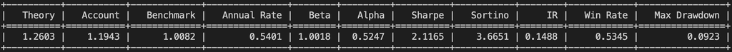

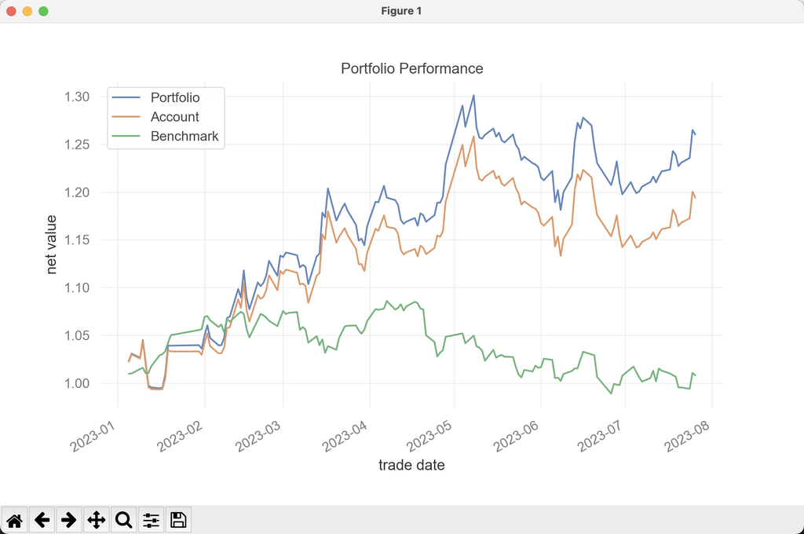

策略净值曲线

下图为日志示例：

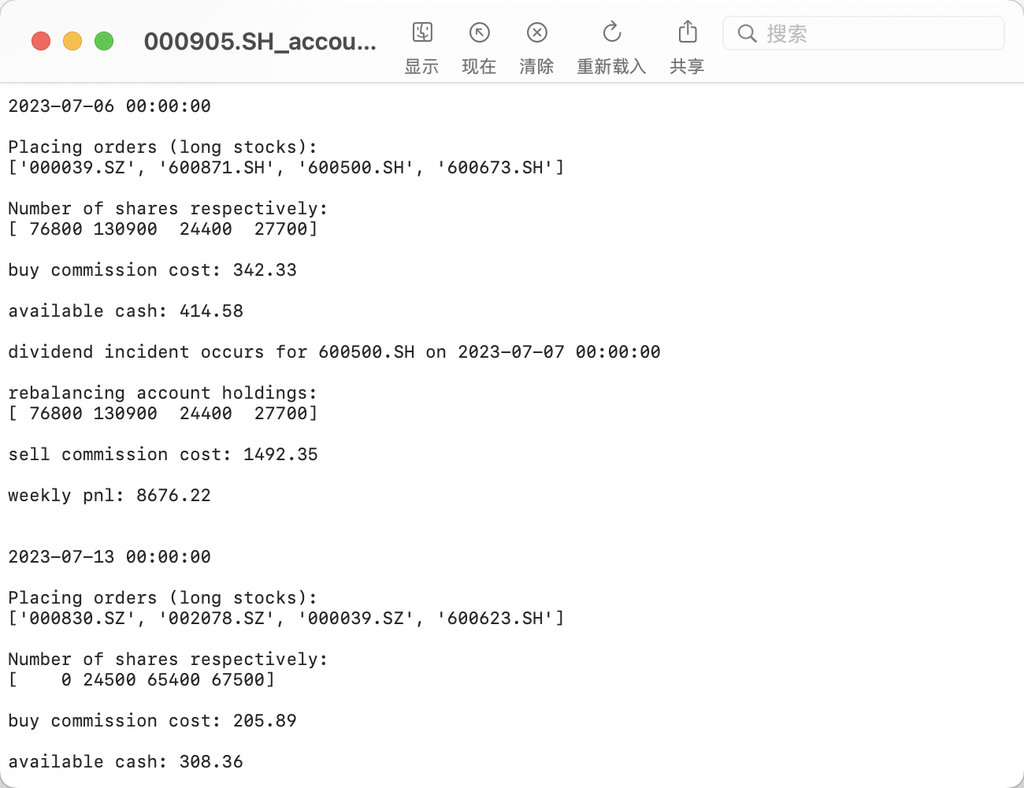

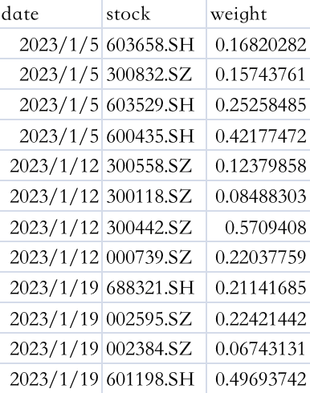